# Lab 2: Data Understanding & Exploratory Data Analysis

- Show All Code
- Hide All Code
- View Source

CRISP-DM Phase 2 — Carseats Case

Author

Prof. Dr. Jörg Schoder

Published

May 19, 2026

## 1 Learning Objectives and Overview

**NoteLearning Objectives**

- Establish EDA as a mandatory first *step to understand the data* before modelling (e.g. regression analysis)
- Explore the Carseats dataset: structure, variable types, distributions
- Understand what EDA is (**descriptive** and **inductive**)…
- …and, equally importantly, what it is *not* (confirmatory, predictive, inferential)
- Recognise why EDA-derived hypotheses cannot be tested on the same data — and know what to do instead
- Visualise bivariate relationships and formulate hypotheses for modelling

**Scenario:** You are the data scientist of a retail chain with 400 stores. The business goal (CRISP-DM Phase 1) is already defined: identify underperforming stores so that management can take targeted action. Before any model is built, the data must be understood. That is CRISP-DM Phase 2: **Data Understanding** — the focus of this lab.

## 2 🧭 How to Navigate This Lab

| Symbol | Box colour | Meaning | When to read |
| --- | --- | --- | --- |
| ⚠️ | **Red — Action Required** | Run code, interpret output, answer questions | **Do this in the live session** |
| 💡 | **Green — Best Practice / Tip** | Coding tips, R functions, shortcuts | Skim in the lab |
| 📚 | **Blue, collapsed — Background Theory** | Concepts, theory, context | Skip in the lab — read at home |
| ℹ️ | **Blue, open — Note** | Short clarifications and reminders | Read when you reach them |

**Normal text** and code chunks are the **main content** — work through them in order. **Background sections** are marked with a **collapsed blue box** and **can be expanded** at any time.

⏱ **40 minutes** for mandatory tasks (A1–A5). Bonus tasks if time permits.

## 3 Icebreaker: Never Trust a Statistic You Haven’t Plotted

Before we turn to the Carseats data, a quick thought experiment. The table below shows descriptive statistics for 13 different datasets: means, standard deviations, and the correlation between x and y.

**Show code: summary statistics**

```r
# Compute key descriptives for all 13 datasets
datasaurus_dozen %>%
  group_by(dataset) %>%                  # one row per dataset
  summarise(
    n      = n(),
    mean_x = mean(x),
    mean_y = mean(y),
    sd_x   = sd(x),
    sd_y   = sd(y),
    cor_xy = cor(x, y)                   # Pearson correlation x-y
  ) %>%
  # --- table formatting ---
  gt() %>%
  fmt_number(columns = where(is.numeric), decimals = 2) %>%
  tab_header(
    title    = "Summary Statistics: Datasaurus Dozen",
    subtitle = "Means, standard deviations, and correlations look virtually identical across all 13 datasets."
  ) %>%
  tab_style(
    style     = cell_fill(color = "#fff8e1"),
    locations = cells_body(rows = dataset == "dino")
  ) %>%
  tab_options(table.font.size = "13px")
```

Summary Statistics: Datasaurus Dozen

Means, standard deviations, and correlations look virtually identical across all 13 datasets.

| dataset | n | mean_x | mean_y | sd_x | sd_y | cor_xy |
| --- | --- | --- | --- | --- | --- | --- |
| away | 142.00 | 54.27 | 47.83 | 16.77 | 26.94 | −0.06 |
| bullseye | 142.00 | 54.27 | 47.83 | 16.77 | 26.94 | −0.07 |
| circle | 142.00 | 54.27 | 47.84 | 16.76 | 26.93 | −0.07 |
| dino | 142.00 | 54.26 | 47.83 | 16.77 | 26.94 | −0.06 |
| dots | 142.00 | 54.26 | 47.84 | 16.77 | 26.93 | −0.06 |
| h_lines | 142.00 | 54.26 | 47.83 | 16.77 | 26.94 | −0.06 |
| high_lines | 142.00 | 54.27 | 47.84 | 16.77 | 26.94 | −0.07 |
| slant_down | 142.00 | 54.27 | 47.84 | 16.77 | 26.94 | −0.07 |
| slant_up | 142.00 | 54.27 | 47.83 | 16.77 | 26.94 | −0.07 |
| star | 142.00 | 54.27 | 47.84 | 16.77 | 26.93 | −0.06 |
| v_lines | 142.00 | 54.27 | 47.84 | 16.77 | 26.94 | −0.07 |
| wide_lines | 142.00 | 54.27 | 47.83 | 16.77 | 26.94 | −0.07 |
| x_shape | 142.00 | 54.26 | 47.84 | 16.77 | 26.93 | −0.07 |

Statistically, these 13 datasets are almost indistinguishable. An algorithm working from summary statistics alone would treat them identically. Now look at the actual data:

**Show code: scatter plots**

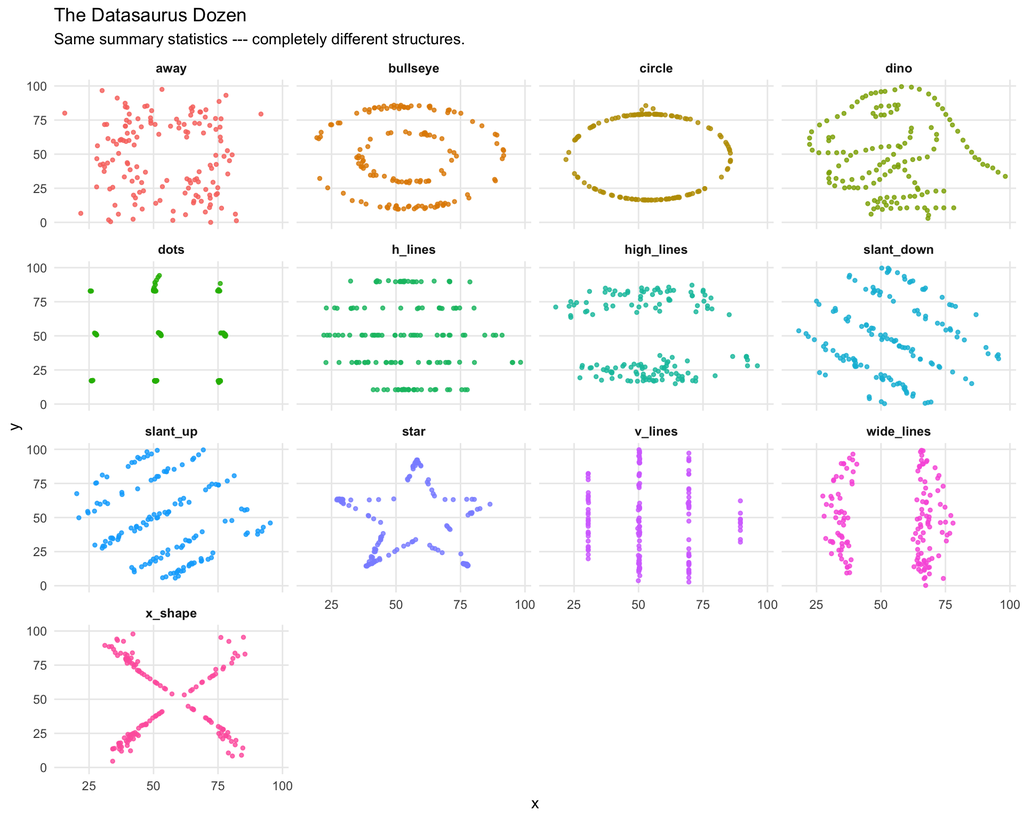

```r
datasaurus_dozen %>%
  ggplot(aes(x = x, y = y, color = dataset)) +
  geom_point(alpha = 0.8, size = 1.0) +        # one point per observation
  facet_wrap(~dataset, ncol = 4) +             # one panel per dataset
  # --- layout ---
  theme_minimal(base_size = 11) +
  theme(
    legend.position  = "none",
    strip.text       = element_text(face = "bold", size = 9),
    panel.grid.minor = element_blank()
  ) +
  labs(
    title    = "The Datasaurus Dozen",
    subtitle = "Same summary statistics --- completely different structures.",
    x = "x", y = "y"
  )
```

**ImportantThe Central Lesson**

The numbers in the table are almost identical. The plots reveal a dinosaur, a star, a circle, an X, and several other completely different shapes — all with the same mean, standard deviation, and correlation.

**Conclusion: summary statistics are a necessary but not sufficient description of data. Visualisation is not optional — it is the primary EDA tool.**

This motivates everything we do in this lab.

## 4 Background: Where We Are in CRISP-DM

In the lecture, **Phase 1 (Business Understanding)** was introduced: the business goal is to identify underperforming stores. The question is now: do our data support this goal? What do they contain? What is their quality? These are Phase 2 questions.

| Phase | Name | Content | Status |
| --- | --- | --- | --- |
| 1 | Business Understanding | Goal: identify underperforming stores | Done (lecture) |
| 2 | Data Understanding | EDA: structure, quality, distributions, patterns | ← This lab |
| 3 | Data Preparation | Cleaning, encoding, feature engineering | Lab 3 |
| 4 | Modelling | Regression model: Sales ~ Price + ... | Lab 3 + Demo |
| 5 | Evaluation | R², residuals, OVB check | Demo + Lab 4 |
| 6 | Deployment | Performance ranking, managerial memo | Lab 4 |

**Note📚 Background: EDA and Data Mining — Orientation**

EDA and Data Mining (DM) are frequently used interchangeably in practice — and there are genuine overlaps. Both are **data-driven and inductive**: they do not wait for a pre-specified hypothesis but search for structure in the data. This distinguishes both from classical confirmatory statistics, which starts from a hypothesis and asks whether the data are consistent with it.

The differences lie in *purpose*, *scale*, and *success criteria*:

**What they share:** Both use statistical summaries and algorithms to separate signal from noise. Both are iterative. Both treat the data as the source of new questions.

**Where they diverge:**

| Aspect | EDA | Data Mining (DM) |
| --- | --- | --- |
| **Central actor** | The human analyst: visualisation serves cognitive understanding | The algorithm: detects patterns at scales humans cannot see |
| **Dimensionality** | Low: 2D/3D visualisations and descriptive statistics | High: hundreds of variables simultaneously (“Big Data”) |
| **Goal** | Understanding, intuition, error detection, hypothesis generation | Extraction of stable, commercially exploitable patterns |
| **Type of insight** | Phenomenological — “What do these data show?” | Pragmatic — “Which patterns are stable enough for profit or prediction?” |
| **Methods** | Plotting, transformation, outlier inspection, correlation | Association rules, clustering, classification, regression models |
| **Human involvement** | Interactive and manual: analyst is in the feedback loop | Automated and scalable |
| **Validation** | Plausibility and visual confirmation | Performance metrics: lift, accuracy, ROI |
| **Causality** | Seeks logical-conceptual connections; generates hypotheses | Stable correlations are sufficient (“black box” acceptable if profitable) |
| **Success** | New question generated; anomaly noticed; pattern understood | Prediction accurate; model deployable; ROI positive |

**NoteThe Grey Zone**

The boundary is genuinely blurry. When we fit a regression line to a scatter plot, are we doing EDA or Data Mining?

- **In EDA:** the line is a *visual summary* — a conditional mean drawn to make a trend perceptible. We look at it, think about it, and decide what to ask next.
- **In DM:** the same line is a *deployed model*, evaluated on held-out data by RMSE and compared against alternatives.

Same technique, different epistemic frame. In this lab, all models are EDA tools — they serve understanding, not deployment. The shift to DM begins in →Lab 3.

### 4.1 The Induction Trap

Both EDA and DM are inductive. This creates a constraint that is easy to overlook.

**WarningHypotheses from EDA Cannot Be Tested on the Same Data**

**The rule:** A hypothesis generated by looking at a dataset cannot be validly tested on that same dataset.

Any pattern you discover inductively will appear confirmed by a statistical test on the same observations — by construction. The p-value will be small, the result will look significant, but you have learned nothing new. This is **circular inference** (or: data dredging, p-hacking).

> *In our case:* After this lab you will have noticed that `ShelveLoc` seems associated with `Sales`. Running a t-test on the same 400 stores to “confirm” this is circular. The data have already been interrogated; they cannot serve as their own judge.

**What to do:** Split the data *before* any exploration: one part for EDA, one part for testing. This is the logic behind train/test splits and **A/B testing** (→ Session 3). In PVA2 we examine what p-values and confidence intervals actually mean. **For now: EDA generates questions — it does not answer them.**

### 4.2 Elements of Exploratory Data Analysis

According to Stoetzer (2020, 3), EDA follows four guiding principles:

1. **Substantive meaning** — The primary goal is *understanding variables* (→ Steps 1–3) and their plausible relationships (→ Steps 4–5), not running formal tests (→ Session 2).
2. **Graphical representation** — Visual inspection of variables and distributions is the primary means of gaining insight.
3. **Exploratory Modelling** — The focus is on tentative hypothesis generation within an iterative process of model specification and re-specification.
4. **Scepticism and parsimony** — The starting points are scepticism, flexibility, and restraint regarding which statistical methods to apply.

## 5 Step 1: Getting to Know the Dataset

### 5.1 Structural Overview

```r
glimpse(tbl_carseats)   # rows, columns, data types, first values
```

```
Rows: 400
Columns: 11
$ Sales       <dbl> 9.50, 11.22, 10.06, 7.40, 4.15, 10.81, 6.63, 11.85, 6.54, …
$ CompPrice   <dbl> 138, 111, 113, 117, 141, 124, 115, 136, 132, 132, 121, 117…
$ Income      <dbl> 73, 48, 35, 100, 64, 113, 105, 81, 110, 113, 78, 94, 35, 2…
$ Advertising <dbl> 11, 16, 10, 4, 3, 13, 0, 15, 0, 0, 9, 4, 2, 11, 11, 5, 0, …
$ Population  <dbl> 276, 260, 269, 466, 340, 501, 45, 425, 108, 131, 150, 503,…
$ Price       <dbl> 120, 83, 80, 97, 128, 72, 108, 120, 124, 124, 100, 94, 136…
$ ShelveLoc   <fct> Bad, Good, Medium, Medium, Bad, Bad, Medium, Good, Medium,…
$ Age         <dbl> 42, 65, 59, 55, 38, 78, 71, 67, 76, 76, 26, 50, 62, 53, 52…
$ Education   <dbl> 17, 10, 12, 14, 13, 16, 15, 10, 10, 17, 10, 13, 18, 18, 18…
$ Urban       <fct> Yes, Yes, Yes, Yes, Yes, No, Yes, Yes, No, No, No, Yes, Ye…
$ US          <fct> Yes, Yes, Yes, Yes, No, Yes, No, Yes, No, Yes, Yes, Yes, N…
```

**Tip💡 What to read from `glimpse()`**

- Number of rows (stores) and columns (variables)
- Data types: `<dbl>` = numeric (double), `<int>` = integer, `<chr>` = character/text, `<fct>` = factor
- First values: do they look plausible?

**Note📚 Background: The R Universe in 4 Levels — A Lego Metaphor**

To understand error messages in R and work confidently with data, you need to answer two questions: *What is my object made of?* (type) and *How is it packaged?* (structure).

**Level 1: The Raw Material (Atomic Types)**

These are the individual Lego bricks. Each brick can only have one property.

- `numeric` (`double` or `integer`): Pure numbers (`138`, `9.50`). You can do arithmetic with them. In `glimpse()` output: `<dbl>` (64-bit decimal) or `<int>` (32-bit whole number).
- `character`: Text / strings (`"Bad"`, `"Zürich"`). Always in quotes. You cannot do arithmetic with them.
- `logical`: Truth values (`TRUE` or `FALSE`). Usually produced by logical tests (e.g. `Sales > 10`).

**Level 2: The Business Hybrid (`factor`)**

One of the most important classes for EDA and modelling.

- `factor`: Looks like text on screen (`"Bad"`, `"Medium"`, `"Good"`), but R stores it internally as an integer with a label (1 = Bad, 2 = Medium, 3 = Good).
- **Why it matters:** Models (regression) and plots (ggplot2) use factors to arrange categorical groups in a meaningful order. A `character` column has no order; a `factor` does.

**Level 3: The Containers (Data Structures)**

How do we combine bricks?

- `vector`: A sequence of bricks of *exactly the same type*. Every column in a dataset is a vector. R enforces homogeneity: mix text and numbers in one vector and R silently converts everything to text.
- `tibble` (or `data.frame`): The familiar “spreadsheet table”. A `tibble` is a collection of equal-length vectors (columns), where each column may have a different type: column 1 is `numeric` (price), column 2 is `factor` (shelf location).

**Level 4: Complex Special Objects**

In R, everything is an object — including the results of analysis. Under the hood, complex objects are usually nested lists (`list`).

- `ggplot` object: When you build a plot, you create an object of class `gg`/`ggplot`. It does not contain a table; it contains a *blueprint* (data + aesthetics + geometry) from which R draws the image. Try `str(my_plot)` to see the structure.
- `lm` object: The result of a linear regression (`lm()`). It contains not just the coefficients but also residuals, fitted values, and model metadata — all packaged as a named list. Try `str(mod)` or `names(mod)` to explore it.

**Practical rule:** When R gives you an unexpected result or error, ask: *What type is this object?* (`class()`) and *How is it structured?* (`str()`).

### 5.2 Comprehensive Summary with `skim()`

`skim()` from the `skimr` package gives a structured, type-aware overview in one call: missing values, quantiles, mean, standard deviation, and a small inline histogram.

```r
tbl_carseats %>% skim()   # type-split summary: missings, quantiles, sparkline histograms
```

Data summary

| Name | Piped data |
| --- | --- |
| Number of rows | 400 |
| Number of columns | 11 |
| _______________________ |  |
| Column type frequency: |  |
| factor | 3 |
| numeric | 8 |
| ________________________ |  |
| Group variables | None |

**Variable type: factor**

| skim_variable | n_missing | complete_rate | ordered | n_unique | top_counts |
| --- | --- | --- | --- | --- | --- |
| ShelveLoc | 0 | 1 | FALSE | 3 | Med: 219, Bad: 96, Goo: 85 |
| Urban | 0 | 1 | FALSE | 2 | Yes: 282, No: 118 |
| US | 0 | 1 | FALSE | 2 | Yes: 258, No: 142 |

**Variable type: numeric**

| skim_variable | n_missing | complete_rate | mean | sd | p0 | p25 | p50 | p75 | p100 | hist |
| --- | --- | --- | --- | --- | --- | --- | --- | --- | --- | --- |
| Sales | 0 | 1 | 7.50 | 2.82 | 0 | 5.39 | 7.49 | 9.32 | 16.27 | ▁▆▇▃▁ |
| CompPrice | 0 | 1 | 124.97 | 15.33 | 77 | 115.00 | 125.00 | 135.00 | 175.00 | ▁▅▇▃▁ |
| Income | 0 | 1 | 68.66 | 27.99 | 21 | 42.75 | 69.00 | 91.00 | 120.00 | ▇▆▇▆▅ |
| Advertising | 0 | 1 | 6.64 | 6.65 | 0 | 0.00 | 5.00 | 12.00 | 29.00 | ▇▃▃▁▁ |
| Population | 0 | 1 | 264.84 | 147.38 | 10 | 139.00 | 272.00 | 398.50 | 509.00 | ▇▇▇▇▇ |
| Price | 0 | 1 | 115.79 | 23.68 | 24 | 100.00 | 117.00 | 131.00 | 191.00 | ▁▂▇▆▁ |
| Age | 0 | 1 | 53.32 | 16.20 | 25 | 39.75 | 54.50 | 66.00 | 80.00 | ▇▆▇▇▇ |
| Education | 0 | 1 | 13.90 | 2.62 | 10 | 12.00 | 14.00 | 16.00 | 18.00 | ▇▇▃▇▇ |

**Note📚 Background: Reading a `skim()` output**

The output is split by data type. For numeric variables, pay attention to:

- `n_missing`: missing values — here 0 for all variables, so no imputation needed.
- `mean` and `p50` (median): if they diverge noticeably, the distribution is skewed.
- `hist`: the inline sparkline gives a first impression of shape.
- `sd`, `p0`, `p100`: range and spread — are there implausible extremes?

### 5.3 Frequency Tables for Categorical Variables

For categorical variables, `count()` and `tabyl()` (from `janitor`) give counts and proportions in one step.

```r
# Count observations per ShelveLoc category
tbl_carseats %>% count(ShelveLoc, sort = TRUE)
```

```
# A tibble: 3 × 2
  ShelveLoc     n
  <fct>     <int>
1 Medium      219
2 Bad          96
3 Good         85
```

```r
# Same with proportions using janitor::tabyl()
tbl_carseats %>%
  tabyl(ShelveLoc) %>%                   # frequency + proportion table
  adorn_pct_formatting(digits = 1) %>%   # format % column
  gt() %>%
  tab_options(table.font.size = "13px")  # --- table size ---
```

| ShelveLoc | n | percent |
| --- | --- | --- |
| Bad | 96 | 24.0% |
| Good | 85 | 21.2% |
| Medium | 219 | 54.8% |

```r
# Cross-tabulation: Urban × US (counts and proportions)
tbl_carseats %>%
  tabyl(Urban, US) %>%                   # 2-way frequency table
  adorn_totals(c("row", "col")) %>%      # add row/column totals
  adorn_percentages("all") %>%           # cell % of grand total
  adorn_pct_formatting(digits = 1) %>%   # format % column
  adorn_ns() %>%                         # append raw counts in parentheses
  gt() %>%
  tab_header(title = "Urban × US: counts (%) of all 400 stores") %>%
  tab_options(table.font.size = "13px")  # --- table size ---
```

Urban × US: counts (%) of all 400 stores

| Urban | No | Yes | Total |
| --- | --- | --- | --- |
| No | 11.5% (46) | 18.0% (72) | 29.5% (118) |
| Yes | 24.0% (96) | 46.5% (186) | 70.5% (282) |
| Total | 35.5% (142) | 64.5% (258) | 100.0% (400) |

### 5.4 Extended Descriptives with `psych::describe()`

**Note📚 Background: What Does `package::function()` Mean?**

In R, `psych::describe()` means: call the function `describe()` from the package `psych`, *without* loading the entire package first with `library(psych)`.

**When to use which:**

| Syntax | Effect | When to use |
| --- | --- | --- |
| `library(psych)` then `describe()` | Loads all of `psych` into your session | When you use many functions from a package |
| `psych::describe()` | Uses only this one function, package not loaded | When you need just one function, or to avoid name conflicts |

**Name conflicts** are the main reason for `::` notation. Both `psych` and `Hmisc` have a function called `describe()`. If both packages are loaded, R will use whichever was loaded last and silently ignore the other. Writing `psych::describe()` makes your intention unambiguous — regardless of what else is loaded.

You will also see `::` used in package documentation and error messages. `dplyr::filter()` means: the `filter()` function specifically from `dplyr` (not from `stats`, which also has a `filter()` function).

`describe()` from the `psych` package adds skewness and kurtosis to the standard summary — useful for assessing distributional shape before deciding on transformations.

```r
tbl_carseats %>%
  select(Sales, Price, Advertising, Income, Age, Population) %>%
  psych::describe() %>%                   # extended descriptives incl. skew & kurtosis
  as_tibble(rownames = "variable") %>%
  select(variable, n, mean, sd, median, min, max, skew, kurtosis) %>%
  # --- table formatting ---
  gt() %>%
  fmt_number(columns = where(is.numeric), decimals = 2) %>%
  tab_style(
    style     = cell_fill(color = "#fff8e1"),
    locations = cells_body(rows = variable == "Sales")   # highlight target variable
  ) %>%
  tab_options(table.font.size = "13px") %>%
  tab_footnote("Skew: |value| < 0.5 = approximately symmetric; > 1 = notably skewed")
```

| variable | n | mean | sd | median | min | max | skew | kurtosis |
| --- | --- | --- | --- | --- | --- | --- | --- | --- |
| Sales | 400.00 | 7.50 | 2.82 | 7.49 | 0.00 | 16.27 | 0.18 | −0.11 |
| Price | 400.00 | 115.79 | 23.68 | 117.00 | 24.00 | 191.00 | −0.12 | 0.41 |
| Advertising | 400.00 | 6.64 | 6.65 | 5.00 | 0.00 | 29.00 | 0.63 | −0.57 |
| Income | 400.00 | 68.66 | 27.99 | 69.00 | 21.00 | 120.00 | 0.05 | −1.10 |
| Age | 400.00 | 53.32 | 16.20 | 54.50 | 25.00 | 80.00 | −0.08 | −1.14 |
| Population | 400.00 | 264.84 | 147.38 | 272.00 | 10.00 | 509.00 | −0.05 | −1.21 |

Skew: |value| < 0.5 = approximately symmetric; > 1 = notably skewed

### 5.5 Quick Data Quality Overview with `DataExplorer`

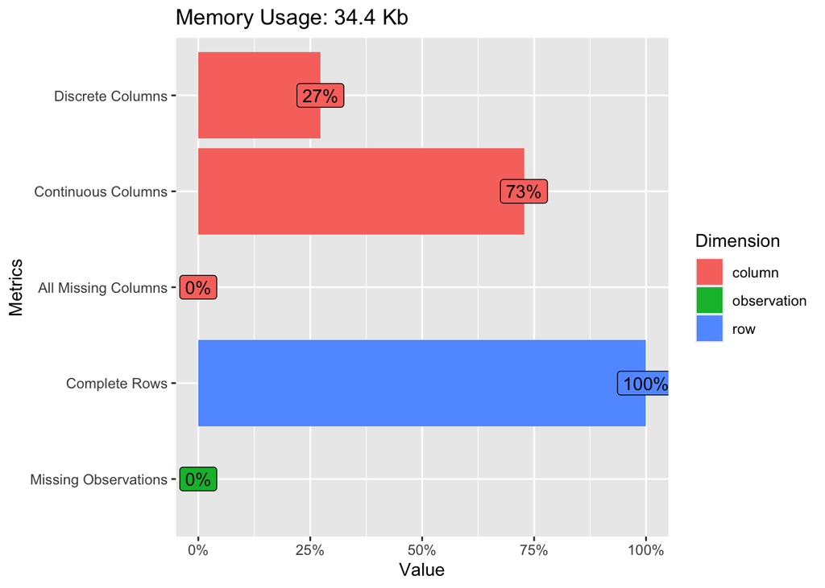

```r
plot_intro(tbl_carseats)   # types, missings, complete rows --- at a glance
```

`plot_intro()` summarises the entire dataset in a single figure: how many variables are continuous vs. discrete, whether any columns or rows are entirely empty, the overall share of missing values, and the proportion of complete rows. For the Carseats data the result is a clean bill of health — no missings, types as expected. In practice this is the first thing to check after import, before any further analysis.

**Important⚠️ A1: Explore the Dataset**

Using `glimpse()`, `skim()`, `tabyl()`, and `describe()`:

1. How many stores and variables does the dataset contain?
2. What is the **range** of `Sales`? What does one unit represent?
3. What proportion of stores have “Good” shelf placement?
4. Which numeric variable has the highest skewness? Does this surprise you?
5. Are there any missing values?

## 6 Step 2: Univariate Distributions

Just as in the bivariate case (Step 4), the choice of visualisation depends on the scale level of the variable:

- **Non-metric (nominal / ordinal):** bar charts show frequencies per category.
- **Metric (interval / ratio):** histograms show the shape of the continuous distribution; kernel density plots add a smooth curve that is independent of bin width choices.

### 6.1 Non-Metric Variables: Bar Charts

For categorical variables, the bar chart is the primary display. The height of each bar encodes the frequency (or proportion) of one category.

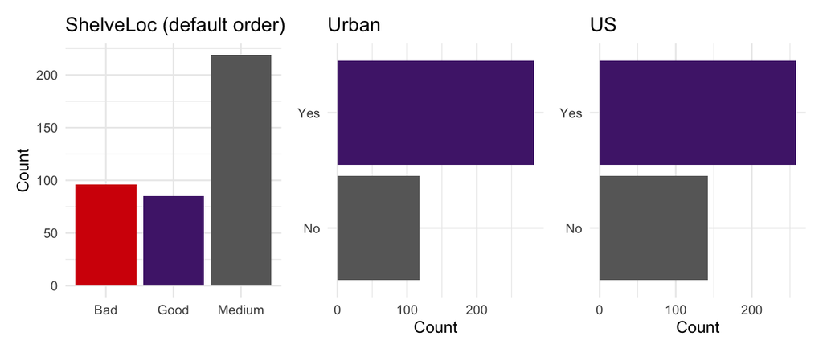

```r
# Bar chart: ShelveLoc (ordinal) --- default level order
p_shelf <- tbl_carseats %>%
  ggplot(aes(x = ShelveLoc, fill = ShelveLoc)) +
  geom_bar() +                                          # height = frequency
  scale_fill_manual(values = c("Bad"    = "#D50006",   # --- colour ---
                               "Medium" = "#686868",
                               "Good"   = "#502479")) +
  labs(title = "ShelveLoc (default order)", x = NULL, y = "Count") +
  theme_minimal(base_size = 10) +
  theme(legend.position = "none")

# Bar chart: Urban (nominal) --- horizontal for readability
p_urban <- tbl_carseats %>%
  ggplot(aes(y = Urban, fill = Urban)) +
  geom_bar() +                                          # horizontal bar
  scale_fill_manual(values = c("Yes" = "#502479", "No" = "#686868")) +
  labs(title = "Urban", x = "Count", y = NULL) +
  theme_minimal(base_size = 10) +
  theme(legend.position = "none")

# Bar chart: US (nominal) --- horizontal
p_us <- tbl_carseats %>%
  ggplot(aes(y = US, fill = US)) +
  geom_bar() +
  scale_fill_manual(values = c("Yes" = "#502479", "No" = "#686868")) +
  labs(title = "US", x = "Count", y = NULL) +
  theme_minimal(base_size = 10) +
  theme(legend.position = "none")

p_shelf + p_urban + p_us
```

**Tip💡 Vertical vs. horizontal bar charts**

Use **vertical** bars (`geom_bar()` with `aes(x = ...)`) when category labels are short and fit below the bars. Use **horizontal** bars (`aes(y = ...)`) when labels are long or when the number of categories makes vertical labels hard to read. Both are produced by `geom_bar()` — only the aesthetic mapping changes.

Look at the left panel carefully. The bars are ordered **Bad — Good — Medium**. **Can you spot the problem?** Good shelf locations should rank higher than Medium — alphabetical ordering does not reflect the natural rank Bad < Medium < Good.

```r
# Check: what class and level order does ShelveLoc have?
class(tbl_carseats$ShelveLoc)
```

```
[1] "factor"
```

```r
levels(tbl_carseats$ShelveLoc)
```

```
[1] "Bad"    "Good"   "Medium"
```

`ShelveLoc` is already a **factor** — so the object class is correct. The issue is that R sorts factor levels **alphabetically by default**. Here, this does not reflect the natural ordinal rank Bad < Medium < Good.

**Note📚 character vs. factor vs. ordered factor**

| Class | Ordering | Typical use |
| --- | --- | --- |
| `character` | None — alphabetical by default | Raw text, free-form labels |
| `factor` | Fixed levels, alphabetical by default if not specified | Nominal categories (Urban, US) |
| `ordered factor` | Levels have a meaningful rank | Ordinal categories (education level, satisfaction) |

The general principle: **scale level determines variable class.** Nominal → `factor`, ordinal → `ordered factor`, metric → `numeric`.

For `ShelveLoc`, a plain `factor` with correctly specified levels is sufficient for EDA and regression. An `ordered factor` would additionally signal the rank Bad < Medium < Good to R’s modelling functions, but is not required here.

Mismatches between content and class are a common source of subtle errors — exactly the kind of thing EDA is designed to catch (→ for background information on other R object classes expand the box 📚 The R Universe in 4 Levels).

Since `ShelveLoc` is an **ordinal variable**, we **prefer a level order that matches its scale level**. Fix it by specifying the correct level sequence:

```r
# Recode ShelveLoc with natural level order (Bad < Medium < Good)
tbl_carseats <- tbl_carseats %>%
  mutate(ShelveLoc = factor(ShelveLoc, levels = c("Bad", "Medium", "Good")))

# Convenience alias used throughout Steps 4 and 5
tbl_cs <- tbl_carseats

# Define shared colour palette (reused in all subsequent plots)
col_shelf <- c("Bad" = "#D50006", "Medium" = "#686868", "Good" = "#502479")
```

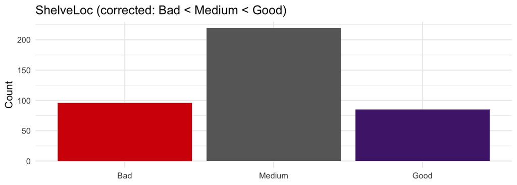

```r
# Bar chart with corrected level order
tbl_carseats %>%
  ggplot(aes(x = ShelveLoc, fill = ShelveLoc)) +
  geom_bar() +                                          # height = frequency
  scale_fill_manual(values = col_shelf) +               # --- colour ---
  labs(title = "ShelveLoc (corrected: Bad < Medium < Good)",
       x = NULL, y = "Count") +                         # --- labels ---
  theme_minimal(base_size = 10) +
  theme(legend.position = "none")
```

### 6.2 Metric Variables: Histogram, Kernel Density, and Log Transformation

#### 6.2.1 Target Variable: `Sales`

A natural first question for any outcome variable: is the distribution symmetric, or does it have a long tail? And — given the standard textbook advice to log-transform business variables — should we apply a log transformation here?

**Important⚠️ A2a: First Impression**

Look at the histogram carefully before reading on.

1. Describe the distribution of raw `Sales` in your own words. Is it symmetric, right-skewed, or left-skewed? How close are mean and median?
2. The standard textbook advice for business variables is to apply a log transformation. Does the log-transformed version look better or worse? What do you observe visually?

**Show code: Sales histogram**

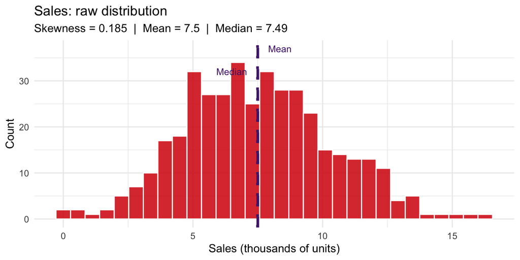

```r
# Pre-compute summary values for labels
skew_sales <- tbl_carseats %>%
  summarise(skew = round(skewness(Sales), 3)) %>% pull(skew)
mean_sales  <- tbl_carseats %>% summarise(m = round(mean(Sales),   2)) %>% pull(m)
med_sales   <- tbl_carseats %>% summarise(m = round(median(Sales), 2)) %>% pull(m)

# Histogram of raw Sales
tbl_carseats %>%
  ggplot(aes(x = Sales)) +
  geom_histogram(bins = 30, fill = "#D50006",              # bar fill
                 color = "white", alpha = 0.85) +
  geom_vline(xintercept = mean_sales,                      # mean line
             color = "#502479", linewidth = 1.2, linetype = "dashed") +
  geom_vline(xintercept = med_sales,                       # median line
             color = "#502479", linewidth = 1.2, linetype = "dotted") +
  annotate("text", x = mean_sales + 0.4, y = 37,          # mean label
           label = "Mean",   color = "#502479", size = 3.2, hjust = 0) +
  annotate("text", x = med_sales  - 0.4, y = 32,          # median label
           label = "Median", color = "#502479", size = 3.2, hjust = 1) +
  labs(                                                     # --- labels ---
    title    = "Sales: raw distribution",
    subtitle = paste0("Skewness = ", skew_sales,
                      "  |  Mean = ", mean_sales,
                      "  |  Median = ", med_sales),
    x = "Sales (thousands of units)", y = "Count"
  ) +
  theme_minimal(base_size = 11)
```

The histogram gives a first impression of shape (variance, skewness, kurtosis). Alternatively **kernel density** plots offer a smooth, bin-width-independent summary of the same distribution:

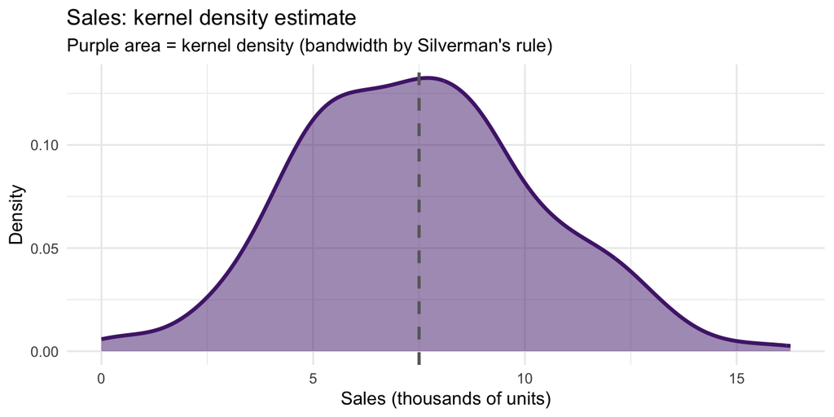

```r
# Kernel density plot of raw Sales
tbl_carseats %>%
  ggplot(aes(x = Sales)) +
  geom_density(color = "#502479", fill = "#502479",        # kernel density curve
               linewidth = 1.1, alpha = 0.5) +
  geom_vline(xintercept = mean_sales,                      # mean line
             color = "#686868", linewidth = 0.9, linetype = "dashed") +
  labs(                                                     # --- labels ---
    title    = "Sales: kernel density estimate",
    subtitle = "Purple area = kernel density (bandwidth by Silverman's rule)",
    x = "Sales (thousands of units)", y = "Density"
  ) +
  theme_minimal(base_size = 11)
```

**Note📚 Background: Kernel Density Estimation**

A **kernel density estimate (KDE)** places a small smooth curve (the *kernel*, typically a Gaussian) at each observation, then sums them up to produce a continuous density curve. It answers the same question as a histogram — what is the shape of the distribution? — but without the arbitrary choice of bin width and bin boundaries.

`geom_density()` in ggplot2 computes the KDE automatically. The *bandwidth* (how wide each kernel is) is chosen by Silverman’s rule by default. A narrower bandwidth reveals more local structure; a wider one produces a smoother curve.

For large datasets, KDE and histogram typically agree. For small datasets, the KDE can smooth over genuine gaps or create artefacts. Both should be inspected together, as shown above.

Raw `Sales` (skewness = 0.185) is only slightly positive, hence already approximately symmetric: mean and median are nearly identical and the distribution is bell-shaped. Given this, should we apply a log transformation?

**Show code: log(Sales) histogram + density**

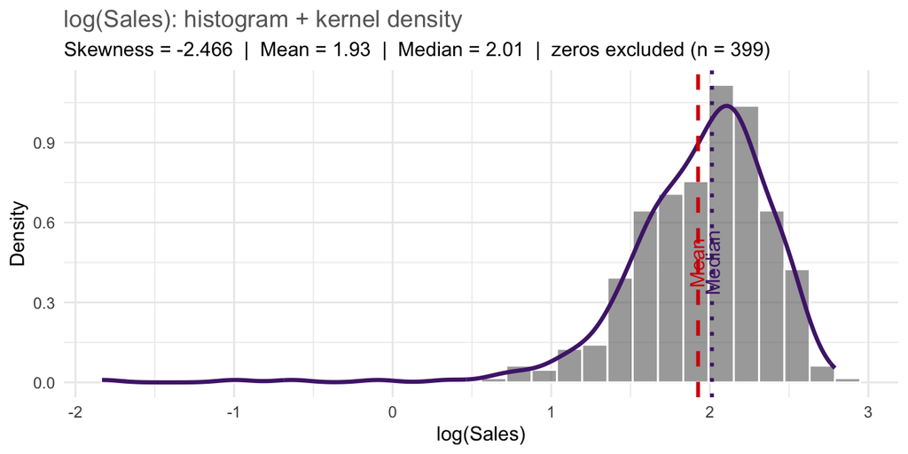

```r
# Summary statistics for log(Sales) for plotting (or use in subtitle)
stats_log <- tbl_carseats %>%
  filter(Sales > 0) %>%
  mutate(log_sales = log(Sales)) %>%
  summarise(
    skew   = round(skewness(log_sales), 3),
    mean   = mean(log_sales),
    median = median(log_sales),
    n      = n()
  )

# Generating the plot-object (after filtering and transforming data)
tbl_carseats %>%
  filter(Sales > 0) %>%
  mutate(log_sales = log(Sales)) %>%
  ggplot(aes(x = log_sales)) +

  # adding geoms to generate layer with histogram & density
  geom_histogram(aes(y = after_stat(density)),
                 bins = 30, fill = "#686868", color = "white", alpha = 0.6) +
  geom_density(color = "#502479", linewidth = 1.1) +

  # adding vertical Lines for mean and median ---
  geom_vline(xintercept = stats_log$mean,
             color = "#D50006", linetype = "dashed", linewidth = 1) +
  geom_vline(xintercept = stats_log$median,
             color = "#502479", linetype = "dotted", linewidth = 1) +
###
  # --- adding labels to lines ---
  annotate("text", x = stats_log$mean - 0.05, y = 0.45,
           label = "Mean", color = "#D50006", angle = 90, vjust = 1) +
  annotate("text", x = stats_log$median + 0.05, y = 0.45,
           label = "Median", color = "#502479", angle = 90, vjust = 0) +

  # Labels & Theme
  labs(
    title    = "log(Sales): histogram + kernel density",
    subtitle = paste0(
      "Skewness = ", stats_log$skew,
      "  |  Mean = ", round(stats_log$mean, 2),
      "  |  Median = ", round(stats_log$median, 2),
      "  |  zeros excluded (n = ", stats_log$n, ")"
    ),
    x = "log(Sales)", y = "Density"
  ) +
  theme_minimal(base_size = 11) +
  theme(plot.title = element_text(color = "#686868"))
```

After the log transformation, skewness becomes -2.466 — considerably more negative (also indicated by the increased difference between mean and median), meaning the transformation introduces left-skewness rather than removing right-skewness — the opposite of its intended effect. **EDA before transformation — always.**

This result is not accidental. It follows from how store-level unit sales are generated. The background box below explains why.

**Note📚 Background: When Is a Log Transformation Appropriate?**

Many econometrics textbooks (Wooldridge, Stock & Watson) present log transformation as a standard remedy for two problems:

- **Right-skewness:** Income, house prices, and firm sizes are almost always right-skewed (a few very large values, many small ones). Logging compresses the upper tail.
- **Interpretability:** Log-transformed models yield coefficients interpretable as elasticities (percentage changes).

Because students typically learn with wage or house price data, a heuristic forms: *“business variable → log-transform.”* This heuristic is often justified — but it conflates two fundamentally different types of business variable.

| Variable type | Typical distribution | Log appropriate? |
| --- | --- | --- |
| **Revenue, wealth, asset prices** | Right-skewed: driven by a few very large values (power-law dynamics) | Usually yes |
| **Unit sales at store level** | Often approximately symmetric | Check empirically — often no |

Why the difference? Unit sales of a stable consumer good across many similar stores are the sum of many independent purchase decisions. The **Central Limit Theorem** tells us that such sums converge to a symmetric distribution regardless of the distribution of individual purchases. Revenue, by contrast, is frequently dominated by a small number of very large transactions — the power-law dynamics that make log transformation genuinely necessary.

**The Carseats data illustrate this perfectly.** `Sales` measures unit sales across 400 stores. The EDA confirms the theoretical expectation: near-symmetry, no need for transformation.

### 6.3 Target Variable: `Advertising`

**Important⚠️ A2b: Log Transformation — Does It Work for Advertising?**

**Part 1: Check the raw skewness**

```r
tbl_carseats %>%
  summarise(skew_adv = skewness(Advertising))   # is Advertising right-skewed?
```

A log transformation looks promising. But try it naively first:

**Part 2: Discover the NaN problem**

```r
tbl_carseats %>%
  mutate(log_adv = log(Advertising)) %>%
  summarise(skew = skewness(log_adv))
```

- What does R return? Is it the expected value?
- Investigate why:

```r
tbl_carseats %>% filter(Advertising == 0) %>% nrow()   # any zeros?
log(0)                                                   # what does log(0) return?
skewness(c(1, 2, 3, -Inf))                              # how does skewness() handle -Inf?
```

- Unlike `Sales = 0`, is `Advertising = 0` a plausible business observation? What does it mean for a store to have zero advertising budget?

**Part 3: Fix it — two approaches**

```r
# Option A: filter zeros, then log
tbl_carseats %>%
  filter(Advertising > 0) %>%
  mutate(log_adv = log(Advertising)) %>%
  summarise(skew = skewness(log_adv))

# Option B: log1p --- no filtering needed
tbl_carseats %>%
  mutate(log_adv = log1p(Advertising)) %>%
  summarise(skew = skewness(log_adv))
```

- Do both approaches give the same result? Which is more appropriate here, and why? (Hint: is `Advertising = 0` an error, or a genuine value?)
- Is the result less skewed than |0.64|? How does this compare to the Sales case?

**Note📚 Background: `log1p()` as a Shortcut — and Its Limitations**

**A note on `log1p()` as a shortcut:**

You may encounter `log1p(x)` = `log(x + 1)` as a convenient alternative to filtering zeros before logging. It avoids `log(0) = -Inf` by shifting the entire distribution up by 1 before taking the log.

However, `log1p` and `log` (after filtering) are *not equivalent* and give different skewness values. The “+1” offset compresses small values more than large ones, which partially offsets the left-skewness. In our data:

- `log(Sales)` after filtering zeros: skewness ≈ -2.466
- `log1p(Sales)` on all 400 stores: skewness ≈ -1.413

Both confirm that the log transformation makes things *worse* — but to different degrees. For our analysis, `log(Sales)` with explicit zero-filtering is the more transparent approach.

## 7 Step 3: Group-Level Descriptives with `group_by()` and `summarise()`

Having described each variable in isolation, we now condition on grouping variables — the first step towards multivariate thinking. `group_by()` combined with `summarise()` is the most direct tidyverse tool for this: it computes descriptive statistics *separately for each group*, making differences that are invisible in marginal summaries immediately apparent. In a full multivariate analysis (regression, Lab 3+), these group differences will reappear as coefficients — but here we describe them first without imposing a model.

### 7.1 Sales by Shelf Location

```r
tbl_carseats %>%
  group_by(ShelveLoc) %>%          # split by shelf location
  summarise(
    n            = n(),
    mean_sales   = round(mean(Sales),   2),
    median_sales = round(median(Sales), 2),
    sd_sales     = round(sd(Sales),     2),
    min_sales    = round(min(Sales),    2),
    max_sales    = round(max(Sales),    2)
  ) %>%
  arrange(desc(mean_sales)) %>%    # sort: highest sales first
  # --- table formatting ---
  gt() %>%
  tab_style(
    style     = cell_fill(color = "#f0fff0"),
    locations = cells_body(rows = ShelveLoc == "Good")
  ) %>%
  tab_style(
    style     = cell_fill(color = "#fff0f0"),
    locations = cells_body(rows = ShelveLoc == "Bad")
  ) %>%
  tab_options(table.font.size = "13px") %>%
  tab_header("Sales by shelf location (ShelveLoc)")
```

Sales by shelf location (ShelveLoc)

| ShelveLoc | n | mean_sales | median_sales | sd_sales | min_sales | max_sales |
| --- | --- | --- | --- | --- | --- | --- |
| Good | 85 | 10.21 | 10.50 | 2.50 | 3.58 | 16.27 |
| Medium | 219 | 7.31 | 7.38 | 2.27 | 0.00 | 13.36 |
| Bad | 96 | 5.52 | 5.21 | 2.36 | 0.37 | 11.67 |

### 7.2 Sales by Urban/US Segment

```r
tbl_carseats %>%
  group_by(Urban, US) %>%          # split by two categorical variables simultaneously
  summarise(
    n          = n(),
    mean_sales = round(mean(Sales), 2),
    sd_sales   = round(sd(Sales),   2),
    .groups = "drop"
  ) %>%
  # --- table formatting ---
  gt() %>%
  tab_options(table.font.size = "13px") %>%
  tab_header("Sales by Urban status and US region")
```

Sales by Urban status and US region

| Urban | US | n | mean_sales | sd_sales |
| --- | --- | --- | --- | --- |
| No | No | 46 | 6.46 | 2.72 |
| No | Yes | 72 | 8.27 | 2.64 |
| Yes | No | 96 | 7.00 | 2.54 |
| Yes | Yes | 186 | 7.71 | 2.96 |

### 7.3 Price Distribution by Shelf Location

```r
# Key question: do better shelves come with higher prices? (foreshadows OVB in Lab 3)
tbl_carseats %>%
  group_by(ShelveLoc) %>%
  summarise(
    mean_price = round(mean(Price), 2),
    sd_price   = round(sd(Price),   2),
    n          = n()
  ) %>%
  # --- table formatting ---
  gt() %>%
  tab_options(table.font.size = "13px") %>%
  tab_header("Price by ShelveLoc",
             subtitle = "Do stores with better shelf space charge higher prices?")
```

Price by ShelveLoc

Do stores with better shelf space charge higher prices?

| ShelveLoc | mean_price | sd_price | n |
| --- | --- | --- | --- |
| Bad | 114.27 | 23.78 | 96 |
| Medium | 115.65 | 23.10 | 219 |
| Good | 117.88 | 25.13 | 85 |

**Important⚠️ A3: Group Comparisons**

1. What is the difference in average sales between “Good” and “Bad” shelf locations? Is this difference large relative to the overall standard deviation of `Sales`?
2. Do stores with better shelf locations also charge higher prices on average? What would this imply for a simple regression of `Sales` on `Price` alone? (This question foreshadows **Omitted Variable Bias** — discussed in →Lab 3.)
3. Extend the group-by analysis: compute mean `Sales` and `Advertising` for the four combinations of Urban × US:

```r
tbl_carseats %>%
  group_by(Urban, US) %>%
  summarise(
    mean_sales = mean(Sales),
    mean_adv   = mean(Advertising),
    n          = n(),
    .groups = "drop"
  )
```

```
# A tibble: 4 × 5
  Urban US    mean_sales mean_adv     n
  <fct> <fct>      <dbl>    <dbl> <int>
1 No    No          6.46    0.413    46
2 No    Yes         8.27    9.90     72
3 Yes   No          7.00    0.552    96
4 Yes   Yes         7.71   10.0     186
```

What pattern do you see? Are there systematic differences in advertising spend?

## 8 Step 4: Bivariate Relationships

### 8.1 Introduction: From Univariate to Bivariate

Having described each variable in isolation, we now ask: *are variables related to each other, and if so, how?* This is the step from univariate to bivariate — and ultimately multivariate — thinking.

**Correlation vs. causation** is the first distinction to make. A correlation tells us that two variables *move together* in the data. It says nothing about *why* they move together. Three explanations are always possible:

1. X causes Y
2. Y causes X
3. A third variable Z causes both (confounding / spurious correlation)

In EDA, we document correlations and formulate hypotheses. We do not claim causality.

### 8.2 Categorical Variables: Visualising Associations

#### 8.2.1 Joint and Marginal Distributions

The starting point for any bivariate analysis of categorical variables is the **joint distribution** — how often each combination of values occurs. From this, we derive **marginal distributions** (the univariate distributions of each variable, ignoring the other) and — crucially — **conditional distributions**.

A **conditional distribution** answers: *given that variable Y takes value $y_k$, how is variable X distributed?* Formally:

$$f(X = x_j \mid Y = y_k) = \frac{f(x_j,\, y_k)}{f(y_k)}$$

Two variables are **statistically independent** if and only if all conditional distributions are identical to the marginal distribution: $f(X \mid Y = y_k) = f(X)$ for all values $y_k$. In other words: knowing the value of Y tells us nothing about X. Any deviation from this equality signals an association.

The Carseats data have two purely nominal variables: `Urban` and `US`. `ShelveLoc` is ordinal and used here as a grouping variable. The factor levels were already corrected in the bar chart section above.

#### 8.2.2 geom_count() and Heatmap

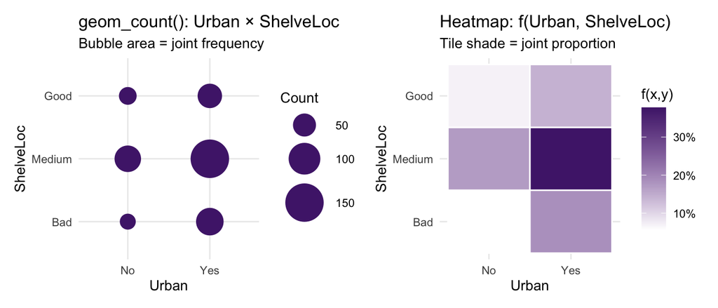

```r
# geom_count: bubble area proportional to joint frequency
p_count <- tbl_cs %>%
  ggplot(aes(x = Urban, y = ShelveLoc)) +
  geom_count(color = "#502479") +             # bubble area ~ count
  scale_size_area(max_size = 12) +
  labs(title = "geom_count(): Urban × ShelveLoc",
       subtitle = "Bubble area = joint frequency",
       size = "Count") +
  theme_minimal(base_size = 10)

# Heatmap: tile colour proportional to joint proportion
p_heat <- tbl_cs %>%
  count(Urban, ShelveLoc) %>%                 # joint frequencies
  mutate(f = n / sum(n)) %>%                  # → proportions
  ggplot(aes(x = Urban, y = ShelveLoc, fill = f)) +
  geom_tile(color = "white", linewidth = 0.5) +  # tile colour ~ proportion
  scale_fill_gradient(low = "white", high = "#502479",
                      labels = scales::percent) +
  labs(title = "Heatmap: f(Urban, ShelveLoc)",
       subtitle = "Tile shade = joint proportion",
       fill = "f(x,y)") +
  theme_minimal(base_size = 10)

p_count + p_heat
```

Both plots display **joint frequencies** — how often each combination of `Urban` and `ShelveLoc` occurs. The cell sizes look roughly proportional to the marginal distributions, suggesting no strong association between shelf quality and urban/rural location.

These plots encode the joint distribution but do not directly show whether the conditional distributions differ across groups. Conditional distribution plots make this comparison explicit.

#### 8.2.3 Conditional Distribution Plots

For each conditional variant we compute the conditional proportions explicitly using `group_by()` + `mutate(f = n/sum(n))` and display them as stacked bar charts — the same visual logic as a mosaic plot, implemented entirely in standard `ggplot2`.

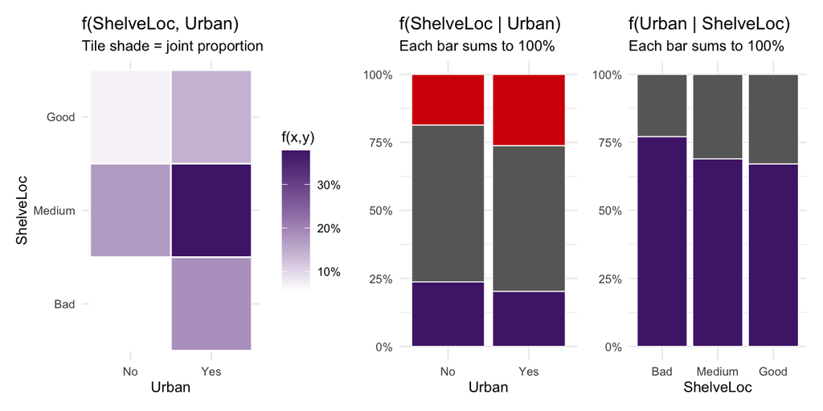

```r
# Panel 1: joint distribution f(ShelveLoc, Urban) as heatmap
p_joint <- tbl_carseats %>%
  count(ShelveLoc, Urban) %>%                      # joint frequencies
  mutate(f = n / sum(n)) %>%                       # joint proportions
  ggplot(aes(x = Urban, y = ShelveLoc, fill = f)) +
  geom_tile(color = "white", linewidth = 0.5) +    # tile shade ~ joint proportion
  scale_fill_gradient(low = "white", high = "#502479",
                      labels = scales::percent) +
  labs(title    = "f(ShelveLoc, Urban)",           # --- labels ---
       subtitle = "Tile shade = joint proportion",
       fill = "f(x,y)") +
  theme_minimal(base_size = 9)

# Panel 2: conditional f(ShelveLoc | Urban)
# For each Urban value: how is ShelveLoc distributed?
p_cond1 <- tbl_carseats %>%
  count(Urban, ShelveLoc) %>%                      # joint frequencies
  group_by(Urban) %>%                              # condition on Urban
  mutate(f_cond = n / sum(n)) %>%                  # conditional proportions
  ggplot(aes(x = Urban, y = f_cond, fill = ShelveLoc)) +
  geom_col(color = "white", linewidth = 0.3) +     # stacked bar = conditional dist.
  scale_fill_manual(values = col_shelf) +          # --- colour ---
  scale_y_continuous(labels = scales::percent) +
  labs(title    = "f(ShelveLoc | Urban)",          # --- labels ---
       subtitle = "Each bar sums to 100%",
       y = NULL, x = "Urban") +
  theme_minimal(base_size = 9) + theme(legend.position = "none")

# Panel 3: conditional f(Urban | ShelveLoc)
# For each ShelveLoc value: how is Urban distributed?
p_cond2 <- tbl_carseats %>%
  count(ShelveLoc, Urban) %>%                      # joint frequencies
  group_by(ShelveLoc) %>%                          # condition on ShelveLoc
  mutate(f_cond = n / sum(n)) %>%                  # conditional proportions
  ggplot(aes(x = ShelveLoc, y = f_cond, fill = Urban)) +
  geom_col(color = "white", linewidth = 0.3) +     # stacked bar = conditional dist.
  scale_fill_manual(values = c("Yes" = "#502479", "No" = "#686868")) +
  scale_y_continuous(labels = scales::percent) +
  labs(title    = "f(Urban | ShelveLoc)",          # --- labels ---
       subtitle = "Each bar sums to 100%",
       y = NULL, x = "ShelveLoc") +
  theme_minimal(base_size = 9) + theme(legend.position = "none")

p_joint + p_cond1 + p_cond2
```

The left panel (joint) shows tile shade proportional to joint frequency. The centre and right panels show **conditional distributions** as stacked bars — each bar sums to 100%.

**Can you spot the difference between joint and conditional?** In the joint heatmap, a darker “Yes” column simply reflects that more stores are urban. In the conditional bar charts, the heights directly answer: *given that a store is urban, how is ShelveLoc distributed?*

The bar heights are nearly identical across “Yes” and “No” in the centre panel — suggesting that `ShelveLoc` and `Urban` are approximately independent.

**Noteℹ️ How to Read a Conditional Bar Chart**

In the **conditional** variants (centre and right), each bar is rescaled to 100%. The height of each colour segment answers: *what proportion of [conditioning group] has this value?*

**Reading example for f(ShelveLoc | Urban) (centre panel):**

Compare the coloured segments between the “Yes” (urban) and “No” (rural) bars:

- **Same heights**: the variables are **statistically independent** — knowing whether a store is urban tells you nothing about its shelf quality.
- **Different heights**: there is an **association** between the two variables.

For `ShelveLoc` and `Urban` in the Carseats data, the proportions are nearly identical — consistent with approximate independence.

**Which panel to use?** The choice depends on the question:

| Panel | Conditions on | Answers |
| --- | --- | --- |
| f(ShelveLoc, Urban) | — | How common is each combination? |
| f(ShelveLoc \| Urban) | Urban | Does shelf quality differ between urban and rural stores? |
| f(Urban \| ShelveLoc) | ShelveLoc | Are good-shelf stores more often in urban locations? |

**Note📚 Background: Three Variants — Formal Definition**

| Plot type | How to compute in R | Formal quantity |
| --- | --- | --- |
| **Joint** f(X, Y) | `count(X,Y) %>% mutate(f = n/sum(n))` | $f(x_j, y_k) = h(x_j, y_k)/n$ |
| **Conditional** f(X\|Y) | `count(X,Y) %>% group_by(Y) %>% mutate(f = n/sum(n))` | $f(x_j \mid y_k) = f(x_j, y_k) / f(y_k)$ |
| **Conditional** f(Y\|X) | `count(X,Y) %>% group_by(X) %>% mutate(f = n/sum(n))` | $f(y_k \mid x_j) = f(x_j, y_k) / f(x_j)$ |

Statistical independence: $f(x_j \mid y_k) = f(x_j)$ for all $j, k$ — equivalent to $f(x_j, y_k) = f(x_j) \cdot f(y_k)$.

The key insight: computing conditional proportions with `group_by()` + `mutate(f = n/sum(n))` makes explicit exactly what the old mosaic rescaling did implicitly.

### 8.3 Metric Variables: Price and Sales — A First Look

For metric variables, the scatter plot replaces the mosaic: each observation appears as a point in a two-dimensional coordinate system, making the direction, strength, and shape of the relationship directly visible.

**Show code: scatter plot**

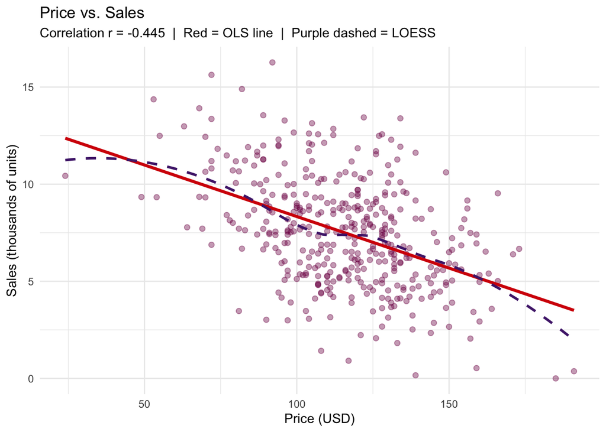

```r
tbl_carseats %>%
  ggplot(aes(x = Price, y = Sales)) +
  geom_point(alpha = 0.4, color = "#7d0a52", size = 1.8) +       # raw observations
  geom_smooth(method = "lm",    color = "#D50006",                # OLS line (linear trend)
              se = FALSE, linewidth = 1.2) +
  geom_smooth(method = "loess", color = "#502479",                # LOESS (linearity check)
              se = FALSE, linewidth = 1, linetype = "dashed") +
  # --- labels ---
  labs(
    title    = "Price vs. Sales",
    subtitle = paste0(
      "Correlation r = ",
      tbl_carseats %>% summarise(r = round(cor(Price, Sales), 3)) %>% pull(r),
      "  |  Red = OLS line  |  Purple dashed = LOESS"
    ),
    x = "Price (USD)", y = "Sales (thousands of units)"
  ) +
  theme_minimal(base_size = 11)
```

The OLS line (red) and the LOESS curve (purple, see note below) are drawn here as **descriptive visual summaries**, not as inferential models. Here, they both tell the same story: the relationship between Price and Sales is approximately linear and negative. This is useful prior information for Lab 3 — a linear model is a reasonable starting point.

**Tip💡 ggplot default: `se = TRUE`**

`geom_smooth()` adds a grey confidence band around the line by default. This band represents inferential uncertainty around the fitted line and only makes sense when treating the data as a sample. In EDA on a population, set `se = FALSE` to avoid a misleading visual.

**Note📚 What is LOESS?**

LOESS (*locally estimated scatterplot smoothing*) fits a smooth curve through the data without assuming a specific functional form — no linearity, no fixed slope. It does this by fitting many small local regressions across the range of x, then connecting them into a continuous curve.

In EDA, LOESS serves as a **linearity check**: if OLS line and LOESS curve run closely together (as here), the linear assumption is supported. If they diverge, a non-linear model or transformation may be needed.

### 8.4 Correlation Measures: From Visual to Numeric

The scatter plots show direction and approximate strength of relationships. For a precise, comparable summary across all variable pairs, we compute correlation coefficients. The right measure depends on the scale level of the variables involved.

**ImportantScale Level Determines the Measure**

> **Rule of thumb:** always use the measure appropriate for the *lower* scale level of the two variables being compared.

| Variable 1 | Variable 2 | Appropriate measure | R function |
| --- | --- | --- | --- |
| Nominal | Nominal | **Cramér’s V** | `rcompanion::cramerV()` |
| Ordinal | Ordinal | **Spearman’s ρ** or **Kendall’s τ** | `cor(..., method = "spearman")` |
| Metric | Metric | **Pearson’s r** | `cor()` / `corrr::correlate()` |
| Metric | Nominal | η² or group comparison | `lm()` + R² |

In the Carseats data: - `Sales`, `Price`, `Advertising`, `Income`, `Age`, `Population` → metric → **Pearson** - `ShelveLoc` → ordinal (Bad < Medium < Good) → **Spearman / Kendall** - `Urban`, `US` → nominal → **Cramér’s V**

**Note📚 Background: Pearson’s r — Intuition and Formula**

**Intuition:** Pearson’s r measures whether two variables move together *linearly*. It answers: when x is above its mean, is y typically also above its mean (positive), below it (negative), or unpredictable (zero)?

**Formula:**

$$r_{XY} = \frac{s_{XY}}{s_X \cdot s_Y} = \frac{\sum_{i=1}^n (x_i - \bar{x})(y_i - \bar{y})}{\sqrt{\sum_{i}(x_i - \bar{x})^2} \cdot \sqrt{\sum_{i}(y_i - \bar{y})^2}}$$

The numerator is the **covariance** — the average product of deviations from the mean. The denominator scales it by the product of standard deviations, making $r$ dimensionless and bounded between $-1$ and $+1$.

**Key properties:**

- $r = +1$: perfect positive linear relationship
- $r = -1$: perfect negative linear relationship
- $r = 0$: no *linear* relationship (but non-linear relationships may exist!)
- $r$ is symmetric: $r_{XY} = r_{YX}$

**Effect size conventions** (Cohen, 1988):

| $\|r\|$ | Interpretation |
| --- | --- |
| $> 0.1$ | Small effect |
| $> 0.3$ | Medium effect |
| $> 0.5$ | Large effect |

**Important limitation:** Pearson’s r only captures *linear* associations. Two variables can have $r = 0$ and still be strongly related non-linearly — the Datasaurus Dozen showed us exactly this.

#### 8.4.1 Pearson Correlation Matrix

```r
# Compute pairwise Pearson correlations
cor_mat <- tbl_carseats %>%
  select(Sales, Price, Advertising, Income, Age, Population) %>%
  cor() %>%          # Pearson correlation matrix → returns a matrix, not a tibble
  round(3)
```

**Show code: heatmap table**

```r
# Display as colour-coded heatmap table
cor_mat %>%
  as_tibble(rownames = "variable") %>%      # matrix → tibble for gt()
  gt() %>%
  fmt_number(columns = where(is.numeric), decimals = 3) %>%
  data_color(                               # --- colour gradient ---
    columns = where(is.numeric),
    rows    = everything(),
    palette = c("#D50006", "white", "#502479"),
    domain  = c(-1, 1)
  ) %>%
  tab_options(table.font.size = "12px") %>% # --- table size ---
  tab_header("Pearson correlation matrix (numeric variables)")
```

Pearson correlation matrix (numeric variables)

| variable | Sales | Price | Advertising | Income | Age | Population |
| --- | --- | --- | --- | --- | --- | --- |
| Sales | 1.000 | −0.445 | 0.270 | 0.152 | −0.232 | 0.050 |
| Price | −0.445 | 1.000 | 0.045 | −0.057 | −0.102 | −0.012 |
| Advertising | 0.270 | 0.045 | 1.000 | 0.059 | −0.005 | 0.266 |
| Income | 0.152 | −0.057 | 0.059 | 1.000 | −0.005 | −0.008 |
| Age | −0.232 | −0.102 | −0.005 | −0.005 | 1.000 | −0.043 |
| Population | 0.050 | −0.012 | 0.266 | −0.008 | −0.043 | 1.000 |

**Show code: ranked correlations**

```r
# Rank predictors by strength of linear association with Sales
cor_mat %>%
  as_tibble(rownames = "variable") %>%
  select(variable, Sales) %>%
  filter(variable != "Sales") %>%          # remove self-correlation
  arrange(desc(abs(Sales))) %>%            # sort by absolute value
  # --- table formatting ---
  gt() %>%
  fmt_number(columns = Sales, decimals = 3) %>%
  tab_options(table.font.size = "13px") %>%
  tab_header("Pearson correlation with Sales --- ranked by absolute value")
```

Pearson correlation with Sales --- ranked by absolute value

| variable | Sales |
| --- | --- |
| Price | −0.445 |
| Advertising | 0.270 |
| Age | −0.232 |
| Income | 0.152 |
| Population | 0.050 |

#### 8.4.2 The `corrr` Package: Tidy Correlation Analysis

Notice that `cor_mat` above is a matrix, not a tibble:

```r
# cor() returns a matrix --- this breaks the pipe workflow
cor_mat %>% class()     # "matrix" "array" --- not a tibble!
```

```
[1] "matrix" "array"
```

This means every further processing step requires `as_tibble()` first. The `corrr` package solves this: `correlate()` returns a tibble directly, so the result flows seamlessly into `shave()`, `fashion()`, `focus()`, `gt()`, or any `dplyr` operation without conversion.

```r
# correlate(): tidy alternative to cor() --- returns a tibble
tbl_carseats %>%
  select(Sales, Price, Advertising, Income, Age, Population) %>%
  corrr::correlate() %>%                   # Pearson by default, result is a tibble
  corrr::shave() %>%                       # remove upper triangle (redundant)
  corrr::fashion()                         # replace NA with blank, round to 2 dp
```

```
         term Sales Price Advertising Income  Age Population
1       Sales
2       Price  -.44
3 Advertising   .27   .04
4      Income   .15  -.06         .06
5         Age  -.23  -.10        -.00   -.00
6  Population   .05  -.01         .27   -.01 -.04
```

```r
# focus(): select only correlations with Sales
tbl_carseats %>%
  select(Sales, Price, Advertising, Income, Age, Population) %>%
  corrr::correlate() %>%
  corrr::focus(Sales) %>%                  # one column: correlations with Sales only
  arrange(desc(abs(Sales))) %>%            # sort by absolute value
  gt() %>%
  fmt_number(columns = Sales, decimals = 3) %>%
  tab_options(table.font.size = "13px") %>%
  tab_header("Correlations with Sales (corrr::focus)")
```

Correlations with Sales (corrr::focus)

| term | Sales |
| --- | --- |
| Price | −0.445 |
| Advertising | 0.270 |
| Age | −0.232 |
| Income | 0.152 |
| Population | 0.050 |

**Tip💡 `corrr` Key Functions**

| Function | What it does |
| --- | --- |
| `correlate()` | Computes correlation matrix as a tibble (Pearson by default) |
| `shave()` | Sets the upper triangle to `NA` (removes redundancy) |
| `focus(var)` | Returns only correlations with selected variable(s) |
| `fashion()` | Pretty-prints: removes `NA`, rounds to 2 decimal places |
| `network_plot()` | Visualises correlation structure as a network |

The key advantage: all outputs are tibbles that flow seamlessly into `gt()`, `ggplot()`, or further `dplyr` operations — no `as_tibble()` workaround needed.

**Important⚠️ A4: Bivariate Analysis**

1. Which numeric variable has the **strongest** linear correlation with `Sales`? Which has the weakest?
2. Are there pairs of *predictors* that are strongly correlated with each other (potential multicollinearity)? Why would this matter in a regression model?
3. Look at the scatterplot matrix below (Section 4.6). The `ShelveLoc` colouring reveals subgroup differences invisible in aggregated correlations:
   - Does the slope of the Price–Sales relationship look different across ShelveLoc groups?
   - What does this imply for modelling?

### 8.5 Scatterplot Matrix: Putting It All Together

`ggpairs()` integrates everything introduced in Step 4 into a single matrix view: the **diagonal** shows univariate kernel density plots (→ Step 2.2), the **lower triangle** shows pairwise scatter plots (→ Section 4.3), and the **upper triangle** shows Pearson correlation coefficients (→ Section 4.5).

**Show code: scatterplot matrix (original level order)**

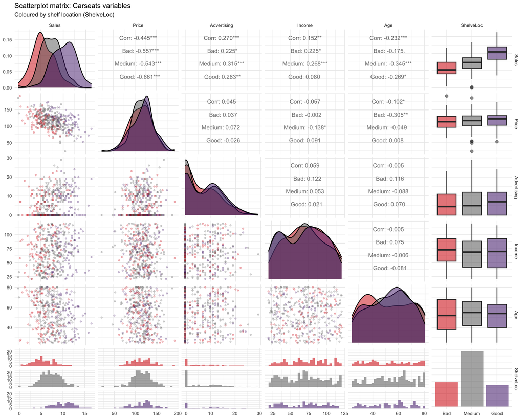

```r
tbl_carseats %>%
  select(Sales, Price, Advertising, Income, Age, ShelveLoc) %>%
  ggpairs(
    aes(color = ShelveLoc, alpha = 0.4),
    upper = list(continuous = wrap("cor", size = 2.8)),            # correlations (upper triangle)
    lower = list(continuous = wrap("points",                       # scatterplots (lower triangle)
                                   alpha = 0.25, size = 0.7)),
    diag  = list(continuous = wrap("densityDiag", alpha = 0.5))   # densities (diagonal)
  ) +
  # --- layout ---
  scale_color_manual(values = c("Bad" = "#D50006", "Medium" = "#686868", "Good" = "#502479")) +
  scale_fill_manual( values = c("Bad" = "#D50006", "Medium" = "#686868", "Good" = "#502479")) +
  theme_minimal(base_size = 8) +
  labs(title    = "Scatterplot matrix: Carseats variables",
       subtitle = "Coloured by shelf location (ShelveLoc)")
```

## 9 Step 5: Boxplots and Conditional Distributions

### 9.1 Visualising Group Distributions

Boxplots add a second perspective to the group-level summaries from Step 3: instead of a single mean, they show the full distributional shape — median, interquartile range, whiskers, and outliers — *per group*. The two key questions from A3 reappear here visually: how much do Sales differ across shelf locations, and do stores with better shelf space also charge higher prices?

Both plots use `ShelveLoc` with corrected level order (Bad < Medium < Good).

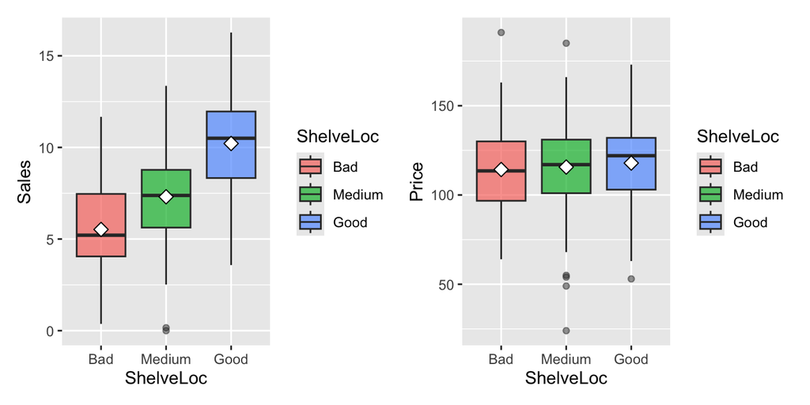

```r
# Shared colour palette (defined once, reused across all plots in this section)
col_shelf <- c("Bad" = "#D50006", "Medium" = "#686868", "Good" = "#502479")

# Recode factor levels for correct x-axis order
tbl_cs <- tbl_carseats %>%
  mutate(ShelveLoc = factor(ShelveLoc, levels = c("Bad", "Medium", "Good")))

# Left panel: Sales distribution per ShelveLoc group
p1 <- tbl_cs %>%
  ggplot(aes(x = ShelveLoc, y = Sales, fill = ShelveLoc)) +
  geom_boxplot(alpha = 0.7, outlier.alpha = 0.5) +              # distribution per group
  stat_summary(fun = mean, geom = "point",                      # add mean as diamond
               shape = 23, size = 3, fill = "white")

# Right panel: Price distribution per ShelveLoc group
p2 <- tbl_cs %>%
  ggplot(aes(x = ShelveLoc, y = Price, fill = ShelveLoc)) +
  geom_boxplot(alpha = 0.7, outlier.alpha = 0.5) +              # distribution per group
  stat_summary(fun = mean, geom = "point",
               shape = 23, size = 3, fill = "white")

p1 + p2   # side by side (patchwork)
```

**Show code: colours, labels & theme**

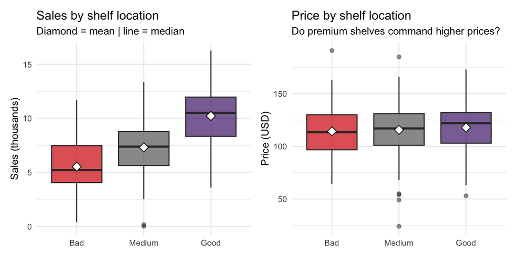

```r
p1 <- tbl_cs %>%
  ggplot(aes(x = ShelveLoc, y = Sales, fill = ShelveLoc)) +
  geom_boxplot(alpha = 0.7, outlier.alpha = 0.5) +
  stat_summary(fun = mean, geom = "point", shape = 23, size = 3, fill = "white") +
  scale_fill_manual(values = col_shelf) +      # --- colour ---
  labs(title    = "Sales by shelf location",   # --- labels ---
       subtitle = "Diamond = mean | line = median",
       x = NULL, y = "Sales (thousands)") +
  theme_minimal(base_size = 10) +              # --- theme ---
  theme(legend.position = "none")

p2 <- tbl_cs %>%
  ggplot(aes(x = ShelveLoc, y = Price, fill = ShelveLoc)) +
  geom_boxplot(alpha = 0.7, outlier.alpha = 0.5) +
  stat_summary(fun = mean, geom = "point", shape = 23, size = 3, fill = "white") +
  scale_fill_manual(values = col_shelf) +      # --- colour ---
  labs(title    = "Price by shelf location",   # --- labels ---
       subtitle = "Do premium shelves command higher prices?",
       x = NULL, y = "Price (USD)") +
  theme_minimal(base_size = 10) +              # --- theme ---
  theme(legend.position = "none")

p1 + p2
```

The left panel confirms the group-level finding from Step 3: Good > Medium > Bad, with a substantial gap. The right panel raises a flag: stores with better shelf placement tend to charge *higher* prices — not lower. This is the pattern that will reappear in Lab 3 as **Omitted Variable Bias**.

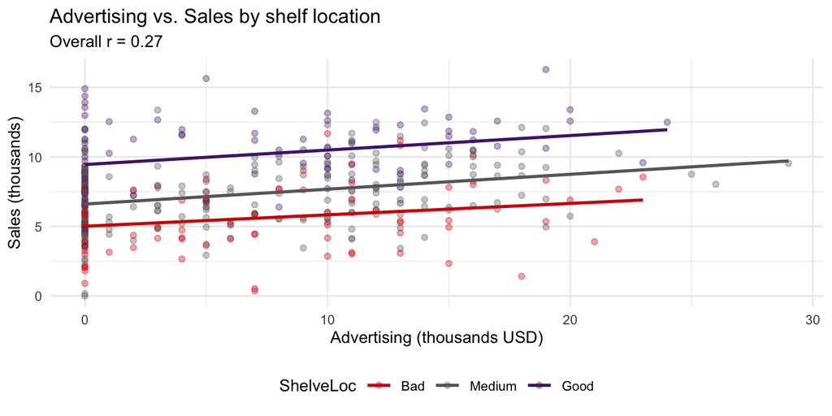

```r
tbl_cs %>%
  ggplot(aes(x = Advertising, y = Sales, color = ShelveLoc)) +
  geom_point(alpha = 0.35, size = 1.4) +                        # raw observations
  geom_smooth(method = "lm", se = FALSE, linewidth = 0.9) +     # OLS trend per group
  scale_color_manual(values = col_shelf) +                       # --- colour ---
  labs(                                                          # --- labels ---
    title    = "Advertising vs. Sales by shelf location",
    subtitle = paste0("Overall r = ",
                      tbl_cs %>%
                        summarise(r = round(cor(Advertising, Sales), 3)) %>%
                        pull(r)),
    x = "Advertising (thousands USD)", y = "Sales (thousands)",
    color = "ShelveLoc"
  ) +
  theme_minimal(base_size = 10) +                               # --- theme ---
  theme(legend.position = "bottom")
```

All three groups show a positive advertising–sales relationship, and the slopes are similar across shelf locations. The vertical separation between the three trend lines reflects the ShelveLoc main effect already seen in the boxplots.

**Tip💡 Alternative: Violin Plots**

Violin plots combine a boxplot with a mirrored density curve, showing not just the five-number summary but the full shape of the distribution per group. They are particularly useful when distributions are bimodal or have unusual shapes that the boxplot’s summary statistics would hide.

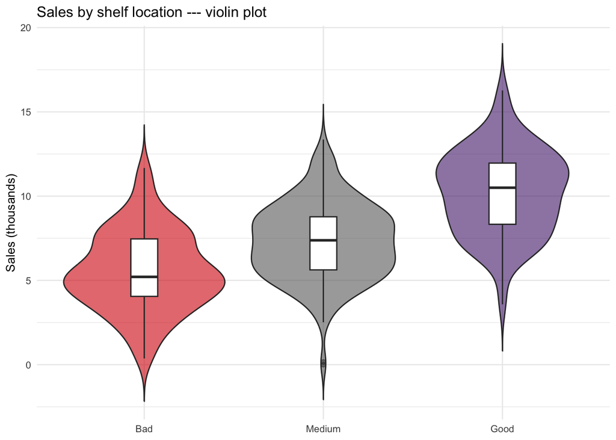

```r
tbl_cs %>%
  ggplot(aes(x = ShelveLoc, y = Sales, fill = ShelveLoc)) +
  geom_violin(alpha = 0.6, trim = FALSE) +         # mirrored density per group
  geom_boxplot(width = 0.15, fill = "white",        # narrow boxplot overlay
               outlier.alpha = 0.5) +
  scale_fill_manual(values = col_shelf) +
  labs(title = "Sales by shelf location --- violin plot",
       x = NULL, y = "Sales (thousands)") +
  theme_minimal(base_size = 10) +
  theme(legend.position = "none")
```

### 9.2 Outlier Detection

Boxplots are not only popular for visualising distributions, but are widely deployed for outlier detection. In Step 2 we found that one or more stores have `Sales = 0`. We filtered these out for the skewness calculation to avoid a numerical problem, but this does *not* mean we should remove them from the analysis.

The right approach is to **identify and inspect** unusual observations, not delete them. An outlier may arise from several causes:

- **Data entry error** (e.g. a typo: `0` instead of `10`) — the only case where deletion is unambiguously justified, if the error is confirmed.
- **Measurement error** (e.g. a system failure that recorded zero sales for a week).
- **True exceptional behaviour** (e.g. a store that genuinely had zero sales due to renovation or a local event) — removing this would bias the analysis.
- **A different underlying process** (e.g. a store that only opened recently and had no sales yet).

The boxplot is the standard EDA tool for flagging such cases visually. Points beyond the whiskers (1.5 × IQR from the quartiles) are plotted individually and invite closer inspection. Flagging is the goal — deletion requires justification.

## 10 Step 6: Formulating Hypotheses

The EDA has surfaced several patterns. The next step is to translate observations into testable hypotheses for the modelling phase (→Labs 3 and 4).

**Important⚠️ A5: Hypotheses for Modelling**

Based on your EDA, formulate **three hypotheses** relevant to the goal “Identify underperforming stores”.

**Structure:** > *“I expect [variable X] to have a [positive/negative] association with Sales because > [substantive reasoning]. This is visible in [specific EDA finding: table/plot].”*

Additionally:

1. The `ggpairs` matrix shows that `ShelveLoc` is associated with both `Price` and `Sales`. What does this imply for a simple regression of `Sales` on `Price` alone? (One sentence is enough — we will formalise this in →Lab 3 as Omitted Variable Bias.)
2. Which variables should be included in the regression model? Which are probably redundant — and why?
3. What variables are **missing** from the dataset that could explain sales differences? (Keyword: *Data Drought*, Thomas, Zikopoulos, and Soule (2025))
4. **The induction trap:** You have now explored all 400 stores. What would you need to do *before* this exploration if you wanted to run valid statistical tests on these hypotheses?

## 11 Bonus Tasks

**Tip B1: Log Transformation for Sales — Apply What You Learned**

In A2b you worked through the log transformation for `Advertising`. Now apply the same sequence to `Sales` and compare.

**Step 1:** Compute the raw skewness:

```r
tbl_carseats %>%
  summarise(skew_sales = skewness(Sales))
```

**Step 2:** Try the naive log transformation:

```r
tbl_carseats %>%
  mutate(log_sales = log(Sales)) %>%
  summarise(skew = skewness(log_sales))
```

**Step 3:** Fix it with `filter()`:

```r
tbl_carseats %>%
  filter(Sales > 0) %>%
  mutate(log_sales = log(Sales)) %>%
  summarise(skew = skewness(log_sales))
```

**Step 4:** Compare with `log1p()`:

```r
tbl_carseats %>%
  mutate(log_sales = log1p(Sales)) %>%
  summarise(skew = skewness(log_sales))
```

- Do both approaches give the same skewness? Why or why not?
- Does the log transformation improve the distributional shape for `Sales`? Compare your result with the histogram from Step 2.

**Step 5: Reflect on `Sales = 0`**

Unlike `Advertising = 0` (a store genuinely spending nothing on advertising), `Sales = 0` raises a harder question. Consider each scenario and discuss what the appropriate analytical response would be:

| Scenario | Implication | Response |
| --- | --- | --- |
| Typo: `0` entered instead of `10` | Data entry error | Correct if confirmable, otherwise flag |
| System failure: sales not recorded | Measurement error | Flag as missing, do not delete |
| Store closed for renovation | True exceptional behaviour | Keep, note as structural outlier |
| Store just opened, no sales yet | Different underlying process | Keep, consider separate modelling |

Which scenario do you consider most plausible for the Carseats dataset? What additional information would you need to decide?

**Tip B2: Beyond Pearson — Spearman, Kendall, and Cramér’s V**

**Why go beyond Pearson?** Pearson’s r measures *linear* associations between *metric* variables. For ordinal variables, or when the relationship is monotone but not linear, rank-based alternatives are more appropriate. For nominal variables, Cramér’s V measures association strength without assuming any ordering.

**Part 1: Spearman vs. Pearson for metric variables**

Spearman’s ρ applies Pearson’s formula to the *ranks* of the observations instead of the raw values. This makes it robust to outliers and captures monotone (but not necessarily linear) relationships.

```r
# Compare Pearson and Spearman for Price vs. Sales
tbl_carseats %>%
  summarise(
    pearson  = cor(Price, Sales, method = "pearson"),
    spearman = cor(Price, Sales, method = "spearman")
  )

# Are they similar? Try with a variable that has outliers: Advertising
tbl_carseats %>%
  summarise(
    pearson  = cor(Advertising, Sales, method = "pearson"),
    spearman = cor(Advertising, Sales, method = "spearman")
  )
```

When Pearson and Spearman differ substantially, it often signals outliers or a non-linear monotone relationship. Which variable shows the largest discrepancy? What might explain it?

**Part 2: Spearman for the full numeric matrix using `corrr`**

```r
# Spearman correlation matrix via corrr
tbl_carseats %>%
  select(Sales, Price, Advertising, Income, Age, Population) %>%
  corrr::correlate(method = "spearman") %>%   # switch method
  corrr::shave() %>%
  corrr::fashion()
```

Compare to the Pearson matrix from Step 4.5. Which correlations change most? What does this tell you?

**Part 3: Kendall’s τ as an alternative to Spearman**

Kendall’s τ is based on *concordant and discordant pairs* rather than ranks. It is more robust than Spearman for small samples and ties.

```r
tbl_carseats %>%
  summarise(
    spearman = cor(Price, Sales, method = "spearman"),
    kendall  = cor(Price, Sales, method = "kendall")
  )
```

Kendall’s τ is typically smaller in absolute value than Spearman’s ρ for the same data. Is this the case here? Are the rankings consistent?

**Part 4: Cramér’s V for nominal variables**

For nominal variables (`Urban`, `US`, `ShelveLoc`), neither Pearson nor Spearman is appropriate. Cramér’s V measures association strength on a scale from 0 (independent) to 1 (perfectly associated).

```r
# install.packages("rcompanion")   # if not yet installed
library(rcompanion)

# Cramér's V: Urban × US
tbl_carseats %>%
  select(Urban, US) %>%
  corrr::colpair_map(rcompanion::cramerV) %>%
  corrr::shave() %>%
  corrr::fashion()

# Cramér's V: all three categorical variables
tbl_carseats %>%
  select(Urban, US, ShelveLoc) %>%
  corrr::colpair_map(rcompanion::cramerV) %>%
  corrr::shave() %>%
  corrr::fashion()
```

Are `Urban` and `US` associated? Is `ShelveLoc` associated with store location? What does this imply for the regression model?

**Part 5: Network plot (visual correlation structure)**

```r
tbl_carseats %>%
  select(Sales, Price, Advertising, Income, Age, Population) %>%
  corrr::correlate() %>%
  corrr::network_plot(min_cor = 0.15,
                      colors = c("#D50006", "white", "#502479"))
```

Which variable clusters emerge? Does the network structure reveal anything the matrix did not?

**Tip B3: Automated EDA Report**

`DataExplorer` can generate a full HTML EDA report in one line:

```r
# One function call generates a self-contained HTML report
create_report(tbl_carseats,
              output_file  = "EDA_Carseats_report.html",
              output_dir   = ".",
              report_title = "Carseats EDA Report")
```

Open the report. Which visualisations are most informative? Which would you include in a presentation to management?

**Tip B4: Missing Data Visualisation**

The Carseats data have no missing values — but real datasets rarely do. Explore a dataset with missings using `visdat` and `naniar`:

```r
library(visdat)
library(naniar)

vis_dat(airquality)            # data types and missing values as heatmap
miss_var_summary(airquality)   # missing count and % per variable
gg_miss_upset(airquality)      # co-occurrence pattern of missings
```

What patterns do you see? Are certain variables always missing together?

**Tip B5: Segmented EDA**

```r
tbl_carseats %>%
  ggplot(aes(x = Price, y = Sales, color = Urban)) +
  geom_point(alpha = 0.4, size = 1.5) +
  geom_smooth(method = "lm", se = FALSE, linewidth = 1.2) +   # OLS per Urban group
  facet_wrap(~US) +                                            # separate panels for US/non-US
  scale_color_manual(values = c("Yes" = "#502479", "No" = "#D50006")) +
  labs(title = "Price vs. Sales by location (Urban) and region (US)",
       x = "Price (USD)", y = "Sales (thousands)") +
  theme_minimal()
```

Any indications of interaction effects between Urban status and US region?

## 12 Summary

[output not shown]

**ImportantKey Messages of This Lab**

1. **EDA is CRISP-DM Phase 2.** It follows Business Understanding and precedes all modelling. Its purpose is data comprehension, not prediction.
2. **Never trust a statistic you haven’t plotted.** The Datasaurus Dozen illustrates this dramatically: identical summary statistics, completely different realities.
3. **EDA and Data Mining are both inductive.** They differ in scale, purpose, and success criteria — not in their logical structure. The OLS line in a scatter plot is EDA when it aids understanding; it becomes a DM artefact when evaluated on new data.
4. **The induction trap.** Hypotheses generated from data cannot be tested on those same data. Plan the data split before exploration.
5. **EDA before transformation.** `Sales` is symmetric (CLT applies to store-level unit sales); the log transformation makes it *worse*. `Advertising` is right-skewed and *is* a candidate for transformation. Always check empirically.
6. **`group_by()` + `summarise()` is the most powerful EDA tool in the tidyverse.** Conditional means reveal patterns that global statistics hide.
7. **Outliers require inspection, not deletion.** A value that looks unusual may reflect an error, a measurement problem, or a genuinely exceptional case. Each case must be examined individually before any decision is made.

**NoteTransition to Lab 3**

In →Lab 3 we fit the **baseline model** `Sales ~ Price`. The EDA findings predict exactly what we will see: a low $R^2$ (Price alone is not enough) and a systematic ShelveLoc pattern in the residual plot — the signature of **Omitted Variable Bias**.

We will also examine the regression output table critically: since we treat the 400 stores as a population, what do “estimate”, “std_error”, and “p_value” actually mean?

## References

Stoetzer, Matthias-W. 2020. *Regressionsanalyse in der empirischen Wirtschafts- und Sozialforschung Band 2: Komplexe Verfahren*. Berlin, Heidelberg: Springer Berlin Heidelberg.

Thomas, Rob, Paul Zikopoulos, and Kate Soule. 2025. *AI Value Creators: Beyond the Generative AI User Mindset*. Sebastopol: O’Reilly Media.